# IC3 Study Space: A Visual Data Story

Daniel Chen

## Introduction

IC3 (the Information Commons on Level 3) is one of the University of Auckland’s most popular study spaces. With over 200 seats spread across a quiet, open-plan floor, it is the go-to destination for students wanting to focus on coursework or find a desk during busy periods.

This visual data story explores **how IC3 is used throughout the day**: How crowded does it get? Does the time of day affect seat availability? What are students actually doing and how noisy is it really?

Data was collected through personal observation in March and May 2026, logging free seat counts, activity types, noise levels, and the time of each observation. A total of **43 observations** were recorded by one observer.

**Key question:** When is IC3 most crowded, what are students doing there, and how noisy does it actually get?

## When Is IC3 Most Crowded?

The first question any student asks before heading to IC3 is: *will I find a seat?*

The bar chart below shows the average number of free seats observed during morning, afternoon, and evening sessions. Afternoons are by far the most crowded, with an average of only around 7 free seats, while evenings see IC3 open up significantly with over 50 free seats on average.

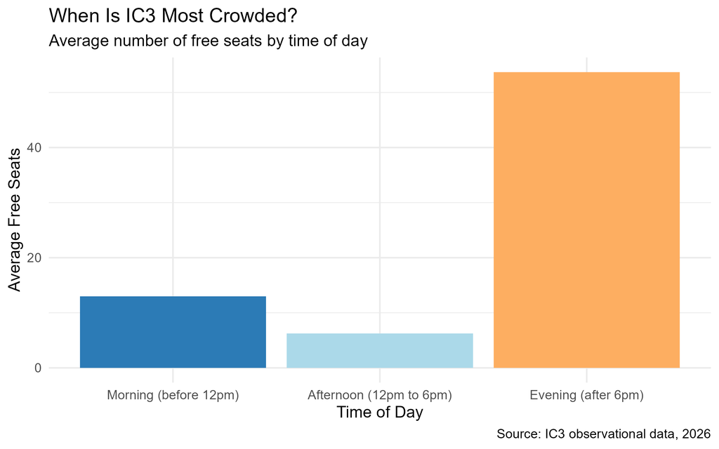

Bar chart showing average free seats in IC3 by time of day. Afternoons have the fewest free seats on average at around 7, making this the most crowded period. Mornings average around 13 free seats. Evenings have by far the most free seats at over 50 on average, making them the quietest time to visit.

Afternoons are the most competitive time to find a seat, likely because students head to IC3 after morning lectures and stay through the day. If you want a guaranteed seat, **evenings after 6pm** are your best bet.

## How Do Free Seats Vary Throughout the Day?

Looking beyond broad time-of-day categories, we can examine exactly **which hours** tend to see the most or least availability by plotting each observation against the actual hour it was recorded.

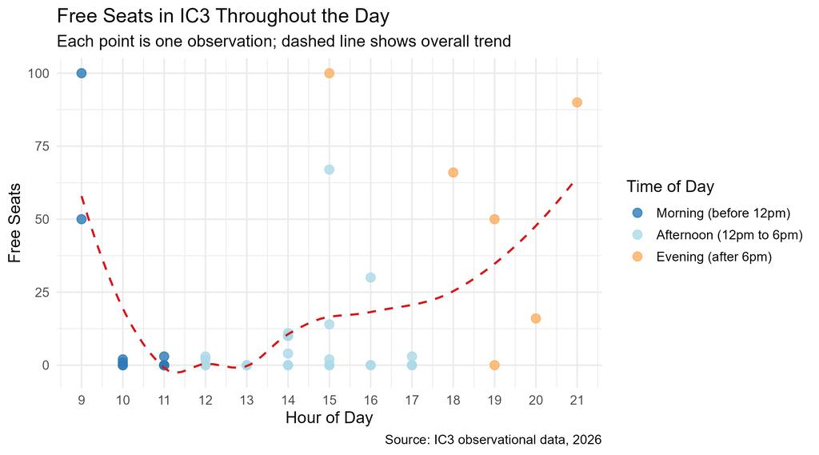

Scatter plot of free seats in IC3 by hour of the day, coloured by time period. Blue points represent morning, light blue represents afternoon, and orange represents evening. A dashed red trend line shows seat availability is very low between 10am and 1pm, then gradually rises through the afternoon and increases sharply in the evening. Morning observations at 9am show high availability, suggesting IC3 fills up quickly after opening.

The trend line shows IC3 is at its most packed between **10am and 1pm**, with nearly all seats taken. Availability gradually recovers through the afternoon and rises sharply after 6pm as students head home. The high outliers at 9am suggest IC3 is largely empty right at opening before quickly filling up.

## What Are People Doing and How Loud Does It Get?

Not all study behaviours create the same atmosphere. The heatmap below maps the **combination of observed activity and noise level**, showing how often each pair was recorded across all 43 observations.

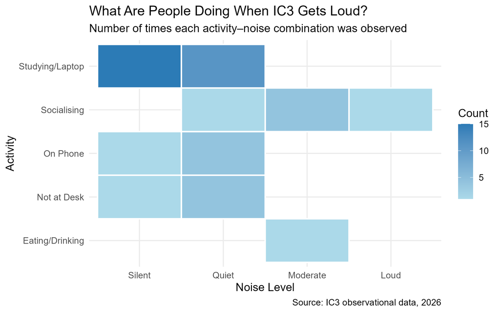

Heatmap showing frequency of activity and noise level combinations in IC3. The darkest cell is Studying or working on a laptop paired with Silent noise, indicating this is by far the most common combination. Socialising is associated with Quiet, Moderate, and Loud noise levels. On Phone and Not at Desk activities occur mostly under Silent or Quiet conditions.

**Data collected via personal observation in IC3, University of Auckland, March to May 2026. All observations recorded using a Google Form.**